# Investigate a Dataset - [Patients noshow appointments-may-2016.csv]

- Introduction
- Data Wrangling
- Exploratory Data Analysis
- Conclusions

## Introduction

This dataset collects information from 100k medical appointments in Brazil and is focused on the question of whether or not patients show up for their appointment. A number of characteristics about the patient are included in each row.

● ‘ScheduledDay’ tells us on what day the patient set up their appointment.

● ‘Neighborhood’ indicates the location of the hospital.

● ‘Scholarship’ indicates whether or not the patient is enrolled in Brasilian welfare program Bolsa Família.

● Be careful about the encoding of the last column: it says ‘No’ if the patient showed up to their appointment, and ‘Yes’ if they did not show up.

### Dataset Description

In this project we have a set of data in csv form to analyze

### Question(s) for Analysis

What factors are important for us to know in order to predict if a patient will show up for their scheduled appointment? for example.

```
Question 1: Is there a interconnection between missing the appointment and the age of the patient?
Question 2: Is there a interconnection between missing the appointment and the Gender of the patient?
Question 3: Is there a interconnection between missing the appointment and not receiving an SMS message?
Question 4: Is there a interconnection between missing the appointment and the Neighbourhood?
```

```python
# import statement for packages to be used
import pandas as pd
import matplotlib.pyplot as plt
import seaborn as snb
import numpy as np
%matplotlib inline
```

## Data Wrangling

In this section, I will load the data, check for the dataset: shape, duplicates, column data type, number of unique value and then the missing values.

### General Properties

```python
# Load your data and print out a few lines. Perform operations to inspect data
#   types and look for instances of missing or possibly errant data.
df = pd.read_csv("noshowappointments-kagglev2-may-2016.csv")
df.head()
```

|  | PatientId | AppointmentID | Gender | ScheduledDay | AppointmentDay | Age | Neighbourhood | Scholarship | Hipertension | Diabetes | Alcoholism | Handcap | SMS_received | No-show |
| --- | --- | --- | --- | --- | --- | --- | --- | --- | --- | --- | --- | --- | --- | --- |
| 0 | 2.987250e+13 | 5642903 | F | 2016-04-29T18:38:08Z | 2016-04-29T00:00:00Z | 62 | JARDIM DA PENHA | 0 | 1 | 0 | 0 | 0 | 0 | No |
| 1 | 5.589978e+14 | 5642503 | M | 2016-04-29T16:08:27Z | 2016-04-29T00:00:00Z | 56 | JARDIM DA PENHA | 0 | 0 | 0 | 0 | 0 | 0 | No |
| 2 | 4.262962e+12 | 5642549 | F | 2016-04-29T16:19:04Z | 2016-04-29T00:00:00Z | 62 | MATA DA PRAIA | 0 | 0 | 0 | 0 | 0 | 0 | No |
| 3 | 8.679512e+11 | 5642828 | F | 2016-04-29T17:29:31Z | 2016-04-29T00:00:00Z | 8 | PONTAL DE CAMBURI | 0 | 0 | 0 | 0 | 0 | 0 | No |
| 4 | 8.841186e+12 | 5642494 | F | 2016-04-29T16:07:23Z | 2016-04-29T00:00:00Z | 56 | JARDIM DA PENHA | 0 | 1 | 1 | 0 | 0 | 0 | No |

```python
# this returns the datatypes of the columns
df.dtypes
```

```
PatientId         float64
AppointmentID       int64
Gender             object
ScheduledDay       object
AppointmentDay     object
Age                 int64
Neighbourhood      object
Scholarship         int64
Hipertension        int64
Diabetes            int64
Alcoholism          int64
Handcap             int64
SMS_received        int64
No-show            object
dtype: object
```

```python
# exploring the shape of the data
df.shape
```

```
(110527, 14)
```

Therefore data consist of 110527 rows and 14 columns

```python
# to check for duplications
df.duplicated().sum()
```

```
0
```

There are no duplicates of the rows

```python
# to check the number of unique values
df['PatientId'].nunique()
```

```
62299
```

There are only 62299 unique value

```python
# to check for missing values
df.info()
```

```
<class 'pandas.core.frame.DataFrame'>
RangeIndex: 110527 entries, 0 to 110526
Data columns (total 14 columns):
 #   Column          Non-Null Count   Dtype
---  ------          --------------   -----
 0   PatientId       110527 non-null  float64
 1   AppointmentID   110527 non-null  int64
 2   Gender          110527 non-null  object
 3   ScheduledDay    110527 non-null  object
 4   AppointmentDay  110527 non-null  object
 5   Age             110527 non-null  int64
 6   Neighbourhood   110527 non-null  object
 7   Scholarship     110527 non-null  int64
 8   Hipertension    110527 non-null  int64
 9   Diabetes        110527 non-null  int64
 10  Alcoholism      110527 non-null  int64
 11  Handcap         110527 non-null  int64
 12  SMS_received    110527 non-null  int64
 13  No-show         110527 non-null  object
dtypes: float64(1), int64(8), object(5)
memory usage: 11.8+ MB
```

There is no missing value

```python
#to get statistical informations about the data
#this work only for data with column type of int and float
df.describe()
```

|  | PatientId | AppointmentID | Age | Scholarship | Hipertension | Diabetes | Alcoholism | Handcap | SMS_received |
| --- | --- | --- | --- | --- | --- | --- | --- | --- | --- |
| count | 1.105270e+05 | 1.105270e+05 | 110527.000000 | 110527.000000 | 110527.000000 | 110527.000000 | 110527.000000 | 110527.000000 | 110527.000000 |
| mean | 1.474963e+14 | 5.675305e+06 | 37.088874 | 0.098266 | 0.197246 | 0.071865 | 0.030400 | 0.022248 | 0.321026 |
| std | 2.560949e+14 | 7.129575e+04 | 23.110205 | 0.297675 | 0.397921 | 0.258265 | 0.171686 | 0.161543 | 0.466873 |
| min | 3.921784e+04 | 5.030230e+06 | -1.000000 | 0.000000 | 0.000000 | 0.000000 | 0.000000 | 0.000000 | 0.000000 |
| 25% | 4.172614e+12 | 5.640286e+06 | 18.000000 | 0.000000 | 0.000000 | 0.000000 | 0.000000 | 0.000000 | 0.000000 |
| 50% | 3.173184e+13 | 5.680573e+06 | 37.000000 | 0.000000 | 0.000000 | 0.000000 | 0.000000 | 0.000000 | 0.000000 |
| 75% | 9.439172e+13 | 5.725524e+06 | 55.000000 | 0.000000 | 0.000000 | 0.000000 | 0.000000 | 0.000000 | 1.000000 |
| max | 9.999816e+14 | 5.790484e+06 | 115.000000 | 1.000000 | 1.000000 | 1.000000 | 1.000000 | 4.000000 | 1.000000 |

The average/mean age is 37, minimium age is -1 (which is not valid and need to be removed), maximum age is 115. majority patients are not handicapped.

### Data Cleaning

```python
#to drop Age with value -1
df.drop(df.query("Age == -1").index,inplace=True)
```

```python
#check Age
df.Age.describe()
```

```
count    110526.000000
mean         37.089219
std          23.110026
min           0.000000
25%          18.000000
50%          37.000000
75%          55.000000
max         115.000000
Name: Age, dtype: float64
```

```python
#to correct column names
df.rename(columns={'No-show':'No_show','Hipertension':'Hypertension'},inplace=True)
df.head()
```

|  | PatientId | AppointmentID | Gender | ScheduledDay | AppointmentDay | Age | Neighbourhood | Scholarship | Hypertension | Diabetes | Alcoholism | Handcap | SMS_received | No_show |
| --- | --- | --- | --- | --- | --- | --- | --- | --- | --- | --- | --- | --- | --- | --- |
| 0 | 2.987250e+13 | 5642903 | F | 2016-04-29T18:38:08Z | 2016-04-29T00:00:00Z | 62 | JARDIM DA PENHA | 0 | 1 | 0 | 0 | 0 | 0 | No |
| 1 | 5.589978e+14 | 5642503 | M | 2016-04-29T16:08:27Z | 2016-04-29T00:00:00Z | 56 | JARDIM DA PENHA | 0 | 0 | 0 | 0 | 0 | 0 | No |
| 2 | 4.262962e+12 | 5642549 | F | 2016-04-29T16:19:04Z | 2016-04-29T00:00:00Z | 62 | MATA DA PRAIA | 0 | 0 | 0 | 0 | 0 | 0 | No |
| 3 | 8.679512e+11 | 5642828 | F | 2016-04-29T17:29:31Z | 2016-04-29T00:00:00Z | 8 | PONTAL DE CAMBURI | 0 | 0 | 0 | 0 | 0 | 0 | No |
| 4 | 8.841186e+12 | 5642494 | F | 2016-04-29T16:07:23Z | 2016-04-29T00:00:00Z | 56 | JARDIM DA PENHA | 0 | 1 | 1 | 0 | 0 | 0 | No |

```python
#to remove unnecessary data
df.drop(['PatientId','AppointmentID','ScheduledDay','AppointmentDay'],axis=1,inplace=True)
df.head()
```

|  | Gender | Age | Neighbourhood | Scholarship | Hypertension | Diabetes | Alcoholism | Handcap | SMS_received | No_show |
| --- | --- | --- | --- | --- | --- | --- | --- | --- | --- | --- |
| 0 | F | 62 | JARDIM DA PENHA | 0 | 1 | 0 | 0 | 0 | 0 | No |
| 1 | M | 56 | JARDIM DA PENHA | 0 | 0 | 0 | 0 | 0 | 0 | No |
| 2 | F | 62 | MATA DA PRAIA | 0 | 0 | 0 | 0 | 0 | 0 | No |
| 3 | F | 8 | PONTAL DE CAMBURI | 0 | 0 | 0 | 0 | 0 | 0 | No |
| 4 | F | 56 | JARDIM DA PENHA | 0 | 1 | 1 | 0 | 0 | 0 | No |

## Exploratory Data Analysis

In this section, there will be computing statistics and creating visualizations with the aim of addressing the research questions posed in the introductory section

```
F    65.0
M    35.0
Name: Gender, dtype: float64
```

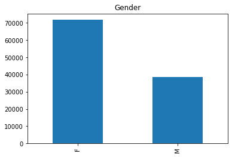

```python
#the ratio of male aand female
print(round(df.Gender.value_counts()/len(df)*100))
# to know the number of male and female
df.Gender.value_counts().plot(kind="bar")
plt.title("Gender");
```

There are more female than male

[figure not shown]

```python
#exploring each column with the values in the y-axis
df.hist(figsize = (20,6.9));
```

```
No     80.0
Yes    20.0
Name: No_show, dtype: float64
```

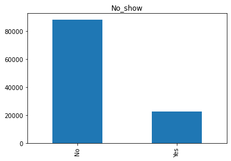

```python
#to explore No_show
print(round(df.No_show.value_counts()/len(df)*100))
df.No_show.value_counts().plot(kind="bar")
plt.title("No_show");
```

#### Observations:

```
●The Age range contain all ages (from 0 to 115) and the majority are the very young age and also between 20 and 55.
●90% of the patients have no scholarship
●More than 80% patients are Hypertension free
●Nearly 95% of all the patients are Diabetes free
●Just 3% of the patients have Alcoholism
●Almost all patients are not handcap
●68% of patients did not received SMS.
●20% of patient missed their appointment.
```

```python
# making masks to use later
show_appointment=df.No_show=='No'
noshow_appointment=df.No_show=='Yes'
df[show_appointment].count(),df[noshow_appointment].count()
```

[output not shown]

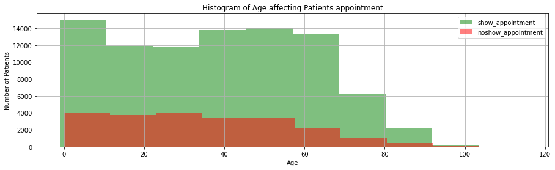

```python
#to check if age affects attending appointment
def attendance(df,col_name,attended,absent):
    plt.figure(figsize=[15,4])
    df[col_name][show_appointment].hist(alpha=0.5,bins=10,color='green',label='show_appointment')
    df[col_name][noshow_appointment].hist(alpha=0.5,bins=10,color='red',label='noshow_appointment')
    plt.legend();
    plt.title('Histogram of Age affecting Patients appointment')
    plt.xlabel('Age')
    plt.ylabel('Number of Patients');
attendance(df,'Age',show_appointment,noshow_appointment)
```

Observation:

There is no strong interconnection between age alone and missing the appointment, although kids and patients in their 60s, 70s and 80s are more likely to show to their appointments